# homework

# HW 2019-11-22

## Exercise 8.3

The Count 5 test for equal variances in Section 6.4 is based on the maximum number of extreme points. Example 6.15 shows that the Count 5 criterion is not applicable for unequal sample sizes. Implement a permutation test for equal variance based on the maximum number of extreme points that applies when sample sizes are not necessarily equal.

```r
# count5 statistic
count5stat <- function(x, y) {
  X <- x - mean(x)
  Y <- y - mean(y)
  outx <- sum(X > max(Y)) + sum(X < min(Y))
  outy <- sum(Y > max(X)) + sum(Y < min(X)) # return 1 (reject) or 0 (do not reject H0)
  return(max(c(outx, outy)))
  }

# generate samples with two different sample sizes
x <- rnorm(30,1,1)
y <- rnorm(25,1,1)


R <- 999
z <- c(x, y)
K <- 1:(length(x)+length(y))
n<-length(x)
set.seed(12345)
reps <- numeric(R)
t0 <- count5stat(x,y)
for (i in 1:R){
  # permutation R times
  k <- sample(K, size = n, replace = FALSE)
  x1 <- z[k]
  y1 <- z[-k]
  reps[i] <- count5stat(x1,y1)
}
p <- mean(abs(c(t0, reps)) >= abs(t0))
print(p)
```

```
## [1] 1
```

## Exercise from Slide P31

- Power comparison (distance correlation test versus ball covariance test)
  - Model 1: $Y = X/4 + e$
  - Model 2: $Y = X/4 × e$
  - $X\sim N(0_{2}, I_{2}), e\sim N(0_{2}, I_{2})$, $X$ and $e$ are independent.

```r
library(Ball)
library(boot)
library(bootstrap)
library(MASS)
```

```r
dCov <- function(x, y){
  x <- as.matrix(x)
  y <- as.matrix(y)
  n <- nrow(x)
  m <- nrow(y)
  if (n != m || n < 2) stop("Sample sizes must agree")
  if (! (all(is.finite(c(x, y))))) stop("Data contains missing or infinite values")
  Akl <- function(x) {
    d <- as.matrix(dist(x))
    m <- rowMeans(d)
    M <- mean(d)
    a <- sweep(d, 1, m)
    b <- sweep(a, 2, m)
    b + M
    }
  A <- Akl(x)
  B <- Akl(y)
  sqrt(mean(A * B))
}
ndCov2 <- function(z, ix, dims) {
  #dims contains dimensions of x and y
  p <- dims[1]
  q <- dims[2]
  d <- p + q
  x <- z[ , 1:p] #leave x as is
  y <- z[ix, -(1:p)] #permute rows of y
  return(nrow(z) * dCov(x, y)^2)
}
```

```r
mu <- c(0,0)
I <- diag(1,2)
m <- 100
set.seed(12345)
R <- 99

pow <- function(n,model){
  p.values <- matrix(NA,m,2)
  for(i in 1:m){
    x <- mvrnorm(n,mu,I)
    e <- mvrnorm(n,mu,I)
    if(model==1) y <- x/4+e
    if(model==2) y <- x/4*e
    z<-cbind(x,y)
    boot.obj <- boot(data = z, statistic = ndCov2, R = R,sim = "permutation", dims = c(2, 2))
    tb <- c(boot.obj$t0, boot.obj$t)
    p.values[i,1] <- mean(tb>=tb[1])
    p.values[i,2] <- bcov.test(x,y,R=R,seed=i*123)$p.value
    }
  alpha <- 0.05;
  pow2 <- colMeans(p.values<alpha)
  return(pow2)
}
```

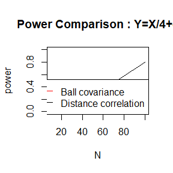

```r
N <- c(10,20,30,50,75,100)
power1 <- matrix(0,6,2)
power2 <- matrix(0,6,2)
for (i in 1:6) {
  power1[i,] <- pow(N[i],1)
  power2[i,] <- pow(N[i],2)
}
plot(N,power1[,1],type = "l",col = "black",ylab = "power",ylim = c(0,1),main = "Power Comparison : Y=X/4+e")
lines(N,power1[,2],col = "red")
legend("bottomright",legend=c("Ball covariance","Distance correlation"),
       col=c("red","black"),lty=1,lwd=1)
```

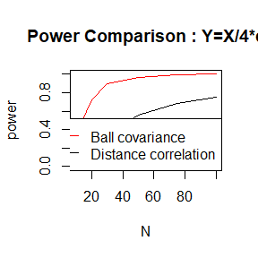

```r
plot(N,power2[,1],type = "l",col = "black",ylab = "power",ylim = c(0,1),main = "Power Comparison : Y=X/4*e")
lines(N,power2[,2],col = "red")
legend("bottomright",legend=c("Ball covariance","Distance correlation"),
       col=c("red","black"),lty=1,lwd=1)
```

# HW 2019-11-29

## Exercise 9.4

Implement a random walk Metropolis sampler for generating the standard Laplace distribution (see Exercise 3.2). For the increment, simulate from a normal distribution. Compare the chains generated when different variances are used for the proposal distribution. Also, compute the acceptance rates of each chain.

- Recall : The standard Laplace distribution has density $f(x)=\frac{1}{2}e^{-|x|}, x\sim\mathbb{R}$.

## Answer

```r
lap.f <- function(x){
  # prop density function of Laplace distribution
  return(1/2*exp(-abs(x)))
}
```

```r
random.walk.Me <- function(sigma, x0, N){
  # function to generate a random walk metropolis chain
  x <- numeric(N)
  x[1] <- x0
  u <- runif(N)
  k <- 0
  for (i in 2:N){
    y <- rnorm(1, x[i-1], sigma)
    if (u[i] <= (lap.f(y)/lap.f(x[i-1]))){
      x[i] <- y
    }else{
      x[i] <- x[i-1]
      k <- k + 1 }
    }
  return(list(x=x, k=k))
}

N <- 2000
sigma <- c(.05, .5, 2, 16)
x0 <- 25
rw1 <- random.walk.Me(sigma[1], x0, N)
rw2 <- random.walk.Me(sigma[2], x0, N)
rw3 <- random.walk.Me(sigma[3], x0, N)
rw4 <- random.walk.Me(sigma[4], x0, N)
```

```r
inverse.F <- function(p){
  if(p>=0.5){
     perc <- -log(1-2*abs(p-0.5))
  }else{perc <- log(1-2*abs(p-0.5))}
  return(perc)
}
perc1 <- inverse.F(0.025)
perc2 <- inverse.F(0.975)
```

Compute the acceptance rates of each chain.

```r
rw.k <- c(rw1$k, rw2$k, rw3$k, rw4$k)
rate.acceptance <- (N-rw.k)/N
rbind(sigma,rate.acceptance)
```

```
##                   [,1]   [,2]   [,3]    [,4]
## sigma           0.0500 0.5000 2.0000 16.0000
## rate.acceptance 0.9785 0.8255 0.5395  0.1035
```

We will find that as the variance becomes larger, the Markov chain converges quickly, but the acceptance rate will also drop quickly.

# HW 2019-12-06

## Exercise 11.1

> The natural logarithm and exponential functions are inverses of each other, so that mathematically log(expx) = exp(logx)=x. Show by example that this property does not hold exactly in computer arithmetic. Does the identity hold with near equality? (See all.equal.)
- Show by example that this property does not hold exactly in computer arithmetic.

```r
x <- runif(1000,0.1,100)
le <- log(exp(x))
el <- exp(log(x))
sum(x==le) # number of x=log(exp(x))
```

```
## [1] 998
```

```r
sum(x==el) # number of x=exp(log(x))
```

```
## [1] 293
```

```r
sum(le==el)# number of log(exp(x))=exp(log(x))
```

```
## [1] 291
```

- The identity does hold with near equality.

```r
eq <- numeric(3)
for (i in 1:1000) {
  eq[1] <- eq[1] + all.equal(x[i],le[i])
  eq[2] <- eq[2] + all.equal(x[i],el[i])
  eq[3] <- eq[3] + all.equal(el[i],le[i])
}
print(eq)
```

```
## [1] 1000 1000 1000
```

## Exercise 11.5

> Write a function to solve the equation
> $$\frac{2\Gamma\left(\frac{k}{2}\right)}{\sqrt{\pi(k-1)}\Gamma\left(\frac{k-1}{2}\right)}\int_{0}^{c_{k-1}}\left(1+\frac{u^{2}}{k-1}\right)^{-k/2}du =\frac{2\Gamma\left(\frac{k+1}{2}\right)}{\sqrt{\pi k}\Gamma\left(\frac{k}{2}\right)} \int_{0}^{c_{k}}\left(1+\frac{u^{2}}{k}\right)^{-(k+1)/2}du$$
> for a, where $c_{k}=\sqrt{\frac{a^{2} k}{k+1-a^{2}}}$. Compare the solutions with the points $A(k)$ in Exercise 11.4.

```r
cupper <- function(k,a){
  return(sqrt(a^2*k/(k+1-a^2)))
}
f1 <- function(u){
  (1+u^2/(k-1))^(-k/2)
}
f2 <- function(u){
  (1+u^2/k)^(-(k+1)/2)
}
sol1 <- function(a){
  # the toot of sol1 is A(k)
  2*gamma(k/2)/(sqrt(pi*(k-1))*gamma((k-1)/2))*integrate(f1,0,cupper(k-1,a))$value-2*gamma((k+1)/2)/(sqrt(pi*k)*gamma(k/2))*integrate(f2,0,cupper(k,a))$value
}

kt <- c(4:25,100)
n <- length(kt)
A1 <- A2 <- numeric(n)
for (i in 1:n) {
  k <- kt[i]
  A1[i] <- uniroot(sol1,c(0.5,sqrt(k)/2+1))$root
}

## Exercise 11.4
sol2 <- function(a){
   # the toot of sol2 is A(k)
   1-pt(cupper(k-1,a),k-1)-1+pt(cupper(k,a),k)
  }
for (i in 1:n) {
   k <- kt[i]
   A2[i] <- uniroot(sol2,c(1e-5,sqrt(k)-1e-5))$root
 }

cbind(df.t=kt,root.ex11.5=A1,root.ex11.4=A2)
```

```
##       df.t root.ex11.5 root.ex11.4
##  [1,]    4    1.492105    1.492103
##  [2,]    5    1.533565    1.533549
##  [3,]    6    1.562774    1.562768
##  [4,]    7    1.584429    1.584421
##  [5,]    8    1.601210    1.601182
##  [6,]    9    1.614520    1.614523
##  [7,]   10    1.625383    1.625387
##  [8,]   11    1.634421    1.634409
##  [9,]   12    1.642056    1.642025
## [10,]   13    1.648526    1.648540
## [11,]   14    1.654168    1.654177
## [12,]   15    1.659095    1.659098
## [13,]   16    1.663433    1.663451
## [14,]   17    1.667281    1.667288
## [15,]   18    1.670725    1.670736
## [16,]   19    1.673824    1.673841
## [17,]   20    1.676639    1.676588
## [18,]   21    1.679154    1.679139
## [19,]   22    1.681472    1.681461
## [20,]   23    1.683596    4.795822
## [21,]   24    1.685550    4.898969
## [22,]   25    1.687355    4.999990
## [23,]  100    1.720600    9.999990
```

- Here we find that when the value of K is small, the results of the two methods are close, but when the value of K is large, especially when we take k = 100 here, the results will be very different. I think the reason for this phenomenon is the problem of calculation accuracy and the error caused by the approximation of our integral. These two reasons lead to a great difference in our A(k).

## A-B-O blood type problem

> Let the three alleles be A, B, and O with allele frequencies p, q, and r. The 6 genotype frequencies under HWE and complete counts are as follows.

| Genotype | AA | BB | OO | AO | BO | AB | Sum |
| --- | --- | --- | --- | --- | --- | --- | --- |
| Frequency | $p^2$ | $q^2$ | $r^2$ | 2pr | 2qr | 2pq | 1 |
| Count | $n_{AA}$ | $n_{BB}$ | $n_{OO}$ | $n_{AO}$ | $n_{BO}$ | $n_{AB}$ | n |

- Observed data:
  - $n_{A·}=n_{AA}+n_{AO}$=28(A-type),
  - $n_{B·}=n_{BB}+n_{BO}$=24(B-type),
  - $n_{OO}$=41(O-type),
  - $n_{AB}$=70(AB-type).
- Use EM algorithm to solve MLE of p and q (consider missing data $n_{AA}$ and $n_{BB}$).
- Show that the log-maximum likelihood values in M-steps are increasing via line plot.

```r
set.seed(999)
library(stats4)

dll <- function(x){
  # root of dll is the p and q that maximum loglikeli
  t <- c(n.ob[5],n.ob[6],n.ob[3],n.ob[1]-n.ob[5],n.ob[2]-n.ob[6],n.ob[4])
  r <- 1-sum(x)
  f1 <- 2*t[1]/x[1]-2*t[3]/r+t[6]/x[1]+t[4]/x[1]-t[4]/r-t[5]/r
  f2 <- 2*t[2]/x[2]-2*t[3]/r+t[6]/x[2]-t[4]/r+t[5]/x[2]-t[5]/r
  c(F1=f1,F2=f2)
}

loglikeli <- function(p){
  # loglikelihood function
  return(2*n.ob[5]*log(p[1])+2*n.ob[6]*log(p[2])+2*n.ob[3]*log(1-p[1]-p[2])+(n.ob[1]-n.ob[5])*log(2*p[1]*(1-p[1]-p[2]))+(n.ob[2]-n.ob[6])*log(2*p[2]*(1-p[1]-p[2]))+n.ob[4]*log(2*p[1]*p[2]))
}

N <- 10000

theta <- matrix(0,N,2)
ll <- numeric(N)
n.ob <- c(28,24,41,70,NaN,NaN)
n.ob[5] <- sample(1:n.ob[1],1)
n.ob[6] <- sample(1:n.ob[2],1)
n <- sum(n.ob[1:4])
library(rootSolve)

for (i in 1:N) {
  theta[i,] <- multiroot(dll,start=c(0.1,0.2))$root
  ll[i] <- loglikeli(theta[i,])
  w <- c(theta[i,],1-sum(theta[i,]))
  o <- numeric(6)
  o[1] <- n*w[1]^2
  o[2] <- n*w[2]^2
  o[3] <- n*w[3]^2
  o[4] <- n*2*w[1]*w[3]
  o[5] <- n*2*w[2]*w[3]
  o[6] <- n*2*w[1]*w[2]
  n.ob <- c(o[1]+o[4],o[2]+o[5],o[3],o[6],o[1],o[2])
}

print(theta[9990:10000,])
```

```
##            [,1]      [,2]
##  [1,] 0.3834356 0.3006135
##  [2,] 0.3834356 0.3006135
##  [3,] 0.3834356 0.3006135
##  [4,] 0.3834356 0.3006135
##  [5,] 0.3834356 0.3006135
##  [6,] 0.3834356 0.3006135
##  [7,] 0.3834356 0.3006135
##  [8,] 0.3834356 0.3006135
##  [9,] 0.3834356 0.3006135
## [10,] 0.3834356 0.3006135
## [11,] 0.3834356 0.3006135
```

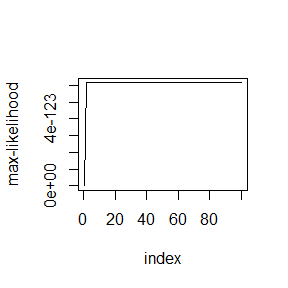

```r
index <- 1:100
plot(index,exp(ll[index]),ylab="max-likelihood",type="l")
```

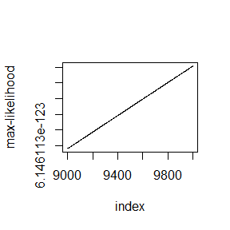

```r
index <- (N-1000):N
plot(index,exp(ll[index]),ylab="max-likelihood",type="l")
```

- Both pictures Show that the log-maximum likelihood values in M-steps are increasing.
- We can also find that the convergence rate of EM algorithm is very fast in this problem.

# HW 2019-12-13

## Exercise 3 from page 204

- Use both for loops and lapply() to ﬁt linear models to the mtcars using the formulas stored in this list:
- formulas <- list(mpg ~ disp, mpg ~ I(1/disp), mpg ~ disp+wt,mpg ~ I(1/disp)+wt)

```r
data("mtcars")
formulas <- list(mpg~disp, mpg~I(1/disp), mpg~disp+wt,mpg~I(1/disp)+wt)
lm.loop <- list()
for (i in 1:4) {
  lm.loop[[i]] <- lm(formulas[[i]],data = mtcars)
}
lm.lapply <- lapply(formulas, lm,data=mtcars)
lm.loop
```

```
## [[1]]
##
## Call:
## lm(formula = formulas[[i]], data = mtcars)
##
## Coefficients:
## (Intercept)         disp
##    29.59985     -0.04122
##
##
## [[2]]
##
## Call:
## lm(formula = formulas[[i]], data = mtcars)
##
## Coefficients:
## (Intercept)    I(1/disp)
##       10.75      1557.67
##
##
## [[3]]
##
## Call:
## lm(formula = formulas[[i]], data = mtcars)
##
## Coefficients:
## (Intercept)         disp           wt
##    34.96055     -0.01772     -3.35083
##
##
## [[4]]
##
## Call:
## lm(formula = formulas[[i]], data = mtcars)
##
## Coefficients:
## (Intercept)    I(1/disp)           wt
##      19.024     1142.560       -1.798
```

```r
lm.lapply
```

```
## [[1]]
##
## Call:
## FUN(formula = X[[i]], data = ..1)
##
## Coefficients:
## (Intercept)         disp
##    29.59985     -0.04122
##
##
## [[2]]
##
## Call:
## FUN(formula = X[[i]], data = ..1)
##
## Coefficients:
## (Intercept)    I(1/disp)
##       10.75      1557.67
##
##
## [[3]]
##
## Call:
## FUN(formula = X[[i]], data = ..1)
##
## Coefficients:
## (Intercept)         disp           wt
##    34.96055     -0.01772     -3.35083
##
##
## [[4]]
##
## Call:
## FUN(formula = X[[i]], data = ..1)
##
## Coefficients:
## (Intercept)    I(1/disp)           wt
##      19.024     1142.560       -1.798
```

## Exercise 4 from page 204

- Fit the model mpg~disp to each of the bootstrap replicates of mtcars in the list below by using a for loop and lapply(). Can you do it without an anonymous function?
  - bootstraps <- lapply(1:10, function(i) {
    - rows <- sample(1:nrow(mtcars), rep = TRUE)
    - mtcars[rows, ] })

```r
boot.sample <- function(i){
  rows <- sample(1:nrow(mtcars), rep = TRUE)
  mtcars[rows, ]
}

lm.loop2 <- list()
for (i in 1:10) {
  lm.loop2[[i]] <- lm(mpg~disp,data = boot.sample(i))
}

lm.lapply2 <- lapply(lapply(1:10, boot.sample),lm,formula=mpg~disp)

lm.loop2
```

```
## [[1]]
##
## Call:
## lm(formula = mpg ~ disp, data = boot.sample(i))
##
## Coefficients:
## (Intercept)         disp
##    29.04442     -0.03932
##
##
## [[2]]
##
## Call:
## lm(formula = mpg ~ disp, data = boot.sample(i))
##
## Coefficients:
## (Intercept)         disp
##    29.13662     -0.03822
##
##
## [[3]]
##
## Call:
## lm(formula = mpg ~ disp, data = boot.sample(i))
##
## Coefficients:
## (Intercept)         disp
##     30.8133      -0.0447
##
##
## [[4]]
##
## Call:
## lm(formula = mpg ~ disp, data = boot.sample(i))
##
## Coefficients:
## (Intercept)         disp
##    29.41507     -0.04147
##
##
```

[output cut: 43 more lines]

```
## lm(formula = mpg ~ disp, data = boot.sample(i))
##
## Coefficients:
## (Intercept)         disp
##    29.61250     -0.03958
##
##
## [[10]]
##
## Call:
## lm(formula = mpg ~ disp, data = boot.sample(i))
##
## Coefficients:
## (Intercept)         disp
##    29.35880     -0.04081
```

```r
lm.lapply2
```

```
## [[1]]
##
## Call:
## FUN(formula = ..1, data = X[[i]])
##
## Coefficients:
## (Intercept)         disp
##    29.25541     -0.03913
##
##
## [[2]]
##
## Call:
## FUN(formula = ..1, data = X[[i]])
##
## Coefficients:
## (Intercept)         disp
##    29.59082     -0.04192
##
##
## [[3]]
##
## Call:
## FUN(formula = ..1, data = X[[i]])
##
## Coefficients:
## (Intercept)         disp
##    28.54548     -0.03809
##
##
## [[4]]
##
## Call:
## FUN(formula = ..1, data = X[[i]])
##
## Coefficients:
## (Intercept)         disp
##    31.18663     -0.04577
##
##
```

[output cut: 43 more lines]

```
## FUN(formula = ..1, data = X[[i]])
##
## Coefficients:
## (Intercept)         disp
##     28.8390      -0.0378
##
##
## [[10]]
##
## Call:
## FUN(formula = ..1, data = X[[i]])
##
## Coefficients:
## (Intercept)         disp
##    27.91905     -0.03654
```

## Exercise 5 from page 204

- For each model in the previous two exercises,extract $R^2$ using the function below.
- rsq <- function(mod) summary(mod)$r.squared

```r
rsq <- function(mod) summary(mod)$r.squared

r2.ex3.loop <- lapply(lm.loop, rsq)
r2.ex3.lapply <- lapply(lm.lapply,rsq)

r2.ex4.loop <- lapply(lm.loop2, rsq)
r2.ex4.lapply <- lapply(lm.lapply2, rsq)

r2.ex3 <- cbind(model=as.character(formulas),r2.ex3.loop,r2.ex3.lapply)
r2.ex4 <- cbind(r2.ex4.loop,r2.ex4.lapply)

r2.ex3
```

```
##      model                  r2.ex3.loop r2.ex3.lapply
## [1,] "mpg ~ disp"           0.7183433   0.7183433
## [2,] "mpg ~ I(1/disp)"      0.8596865   0.8596865
## [3,] "mpg ~ disp + wt"      0.7809306   0.7809306
## [4,] "mpg ~ I(1/disp) + wt" 0.8838038   0.8838038
```

```r
r2.ex4
```

```
##       r2.ex4.loop r2.ex4.lapply
##  [1,] 0.7283588   0.7137732
##  [2,] 0.7027162   0.7332487
##  [3,] 0.7548916   0.6899542
##  [4,] 0.7953467   0.7376026
##  [5,] 0.4922375   0.7626674
##  [6,] 0.7262154   0.7669397
##  [7,] 0.6396368   0.7868589
##  [8,] 0.705891    0.7602861
##  [9,] 0.716635    0.6928586
## [10,] 0.7115339   0.6353946
```

## Exercise 3 from page 214

- The following code simulates the performance of a t-test for non-normal data. Use sapply() and an anonymous function to extract the p-value from every trial.
- trials <- replicate(100,t.test(rpois(10,10),rpois(7,10)),simplify = FALSE)
- Extra challenge: get rid of the anonymous function by using [[ directly.

```r
set.seed(123)
trials <- replicate(100,t.test(rpois(10,10),rpois(7,10)),simplify = FALSE)

# Use sapply() and an anonymous function to extract the p-value from every trial.
pv1 <- sapply(trials, function(x) x$p.value)
# Extra challenge: get rid of the anonymous function by using [[ directly.
pv2 <- sapply(trials,"[[",3)

cbind(pv1,pv2)
```

```
##                 pv1          pv2
##   [1,] 9.813226e-01 9.813226e-01
##   [2,] 1.619096e-05 1.619096e-05
##   [3,] 6.242135e-01 6.242135e-01
##   [4,] 6.693526e-01 6.693526e-01
##   [5,] 5.677105e-01 5.677105e-01
##   [6,] 6.610740e-01 6.610740e-01
##   [7,] 5.951636e-01 5.951636e-01
##   [8,] 5.005347e-01 5.005347e-01
##   [9,] 4.763110e-01 4.763110e-01
##  [10,] 3.429965e-01 3.429965e-01
##  [11,] 8.155394e-01 8.155394e-01
##  [12,] 7.197238e-01 7.197238e-01
##  [13,] 1.244336e-01 1.244336e-01
##  [14,] 2.229164e-01 2.229164e-01
```

[output cut: 86 more lines]

## Exercise 7 from page 214

- Implement mcsapply(), a multicore version of sapply().
- Can you implement mcvapply(), a parallel version of vapply()? Why or why not?

```r
library(parallel)
mcsapply <- function(X, FUN, ..., simplify = TRUE, USE.NAMES = TRUE, chunk.size = NULL){
  # 计算可用线程数，并设置并行使用线程数
  no_cores <- detectCores() - 1
  # 初始化
  cl <- makeCluster(no_cores)
  ans <- parSapply(cl, X, FUN, ..., simplify = TRUE,
            USE.NAMES = TRUE, chunk.size = NULL)
  stopCluster(cl)
  return(ans)
}


# example
mcsapply(trials,function(x) x$p.value)
```

```
##   [1] 9.813226e-01 1.619096e-05 6.242135e-01 6.693526e-01 5.677105e-01
##   [6] 6.610740e-01 5.951636e-01 5.005347e-01 4.763110e-01 3.429965e-01
##  [11] 8.155394e-01 7.197238e-01 1.244336e-01 2.229164e-01 1.113099e-02
##  [16] 4.625765e-01 6.515865e-01 1.658793e-01 9.342672e-01 8.011934e-01
##  [21] 4.627657e-01 5.927934e-01 2.929669e-01 5.737967e-01 3.451537e-02
##  [26] 2.739138e-01 2.656151e-01 8.196695e-01 6.647355e-01 8.056529e-01
##  [31] 5.060850e-01 7.106543e-01 2.321066e-01 1.106223e-01 5.459279e-01
##  [36] 1.865470e-02 2.433776e-01 2.688851e-01 9.819256e-01 4.940184e-01
##  [41] 3.268275e-01 8.000439e-01 9.822499e-01 1.936454e-01 7.390101e-01
##  [46] 3.888930e-02 4.350424e-01 7.434339e-02 5.787441e-01 4.864951e-01
##  [51] 1.476288e-01 5.524909e-01 7.129280e-01 8.683479e-03 9.053256e-02
##  [56] 4.415463e-01 4.955063e-01 1.745328e-01 6.615399e-01 4.479199e-01
##  [61] 2.885849e-01 3.028567e-02 1.018907e-01 1.811861e-02 6.376441e-01
##  [66] 1.408742e-02 9.008128e-02 4.515933e-01 8.703291e-01 7.250768e-01
##  [71] 8.183571e-01 8.465036e-01 8.786838e-01 1.651543e-01 3.951569e-01
##  [76] 1.754280e-01 3.649865e-01 7.224226e-02 6.565152e-01 9.946559e-01
##  [81] 3.715952e-01 8.424336e-02 4.549887e-01 8.530113e-01 1.970777e-01
##  [86] 2.298117e-01 1.148832e-01 7.769502e-01 4.934348e-01 3.526049e-01
##  [91] 2.036013e-01 8.838914e-01 6.474880e-02 4.089082e-01 5.780132e-01
##  [96] 8.011408e-01 5.956061e-01 9.266689e-01 9.923205e-02 1.763972e-01
```

> We can’t implement Mcvapply. The superficial reason is that we cannot find a parVapply similar to parSapply versus sapply. The essential reason I think is that the working mechanism of vapply is causing it to have no way to parallelize.

# HW 2019-12-20

## Exercise

- You have already written an R function for Exercise 9.4 (page 277, Statistical Computing with R).Rewrite an Rcpp function for the same task.
- Compare the generated random numbers by the two functions using **qqplot**.
- Campare the computation time of the two functions with **microbenchmark**.
- Comments your results.

> Exercise9.4: Implement a random walk Metropolis sampler for generating the standard Laplace distribution (see Exercise 3.2).The standard Laplace distribution has density $f(x)=\frac{1}{2}e^{-|x|}, x\sim\mathbb{R}$.

```r
N <- 2000
sigma <- c(.05, .5, 2, 16)
x0 <- 25
```

## Rcpp function

```r
library(Rcpp)
sourceCpp(code = '
          #include <Rcpp.h>
          using namespace Rcpp;

          //[[Rcpp::export]]
          NumericMatrix rwme(double sigma,double xo,int N){
          NumericMatrix x(N,2);
          x(0,0) = xo;
          x(1,0) = 1;
          NumericVector u = runif(N);
          for (int i = 1; i < N ;i++){
            double y = as<double>(rnorm(1, x(i-1,0), sigma));
            double t = exp(-abs(y))/exp(-abs(x(i-1,0)));
            if (u[i] > t){
              x(i,0) = x(i-1,0);
              x(i,1) = 0;
            }
            else{
              x(i,0) = y;
              x(i,1) = 1;}
          };
          return x;
          }')
```

## R function

```r
lap.f <- function(x){
  # prop density function of Laplace distribution
  return(1/2*exp(-abs(x)))
}
randomwalk <- function(sigma, x0, N){
  # function to generate a random walk metropolis chain
  x <- matrix(0,N,2)
  x[1,1] <- x0
  u <- runif(N)
  for (i in 2:N){
    y <- rnorm(1, x[i-1], sigma)
    if (u[i] <= (lap.f(y)/lap.f(x[i-1]))){
      x[i,1] <- y
      x[i,2] <- 1
    }else{
      x[i,1] <- x[i-1]
      x[i,2] <- 0}
    }
  return(x)
}
```

## Genereate random numbers by the two functions

```r
rw1 <- randomwalk(sigma[1], x0, N)
rw2 <- randomwalk(sigma[2], x0, N)
rw3 <- randomwalk(sigma[3], x0, N)
rw4 <- randomwalk(sigma[4], x0, N)
```

```r
rw5 <- rwme(sigma[1], x0, N)
rw6 <- rwme(sigma[2], x0, N)
rw7 <- rwme(sigma[3], x0, N)
rw8 <- rwme(sigma[4], x0, N)
```

## Compare the generated random numbers

```r
acR <- c(sum(rw1[,2]==1),sum(rw2[,2]==1),sum(rw3[,2]==1),sum(rw4[,2]==1))
acC <- c(sum(rw5[,2]==1),sum(rw6[,2]==1),sum(rw7[,2]==1),sum(rw8[,2]==1))
rbind(sigma,acR,acC)
```

```
##          [,1]   [,2] [,3] [,4]
## sigma    0.05    0.5    2   16
## acR   1972.00 1649.0 1066  213
## acC   1957.00 1735.0 1106  189
```

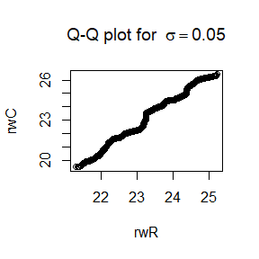

```r
####par(mfrow=c(2,2))
qqplot(rw1[rw1[,2]==1,1],rw5[rw5[,2]==1,1],xlab = "rwR",ylab = "rwC",main = expression("Q-Q plot for" ~~ {sigma==0.05}))
```

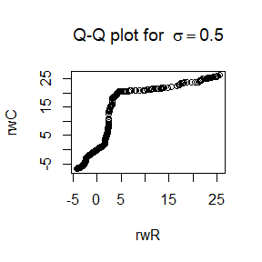

```r
qqplot(rw2[rw2[,2]==1,1],rw6[rw6[,2]==1,1],xlab = "rwR",ylab = "rwC",main = expression("Q-Q plot for" ~~ {sigma==0.5}))
```

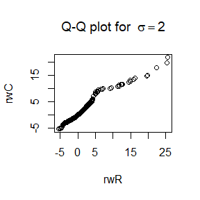

```r
qqplot(rw3[rw3[,2]==1,1],rw7[rw7[,2]==1,1],xlab = "rwR",ylab = "rwC",main = expression("Q-Q plot for" ~~ {sigma==2}))
```

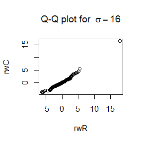

```r
qqplot(rw4[rw4[,2]==1,1],rw8[rw8[,2]==1,1],xlab = "rwR",ylab = "rwC",main = expression("Q-Q plot for" ~~ {sigma==16}))
```

```r
library(microbenchmark)
ts <- microbenchmark(rwR1 <- randomwalk(sigma[1], x0, N) ,rwR2 <- randomwalk(sigma[2], x0, N) ,rwR3 <- randomwalk(sigma[3], x0, N) ,rwR4 <- randomwalk(sigma[4], x0, N) ,rwC1 <- rwme(sigma[1], x0, N) ,rwC2 <- rwme(sigma[2], x0, N) ,rwC3 <- rwme(sigma[3], x0, N)  ,rwC4 <- rwme(sigma[4], x0, N))
summary(ts)[,c(1,3,5,6)]
```

```
##                                  expr      lq  median      uq
## 1 rwR1 <- randomwalk(sigma[1], x0, N) 7348.40 7669.35 8609.25
## 2 rwR2 <- randomwalk(sigma[2], x0, N) 7438.90 7854.00 9263.25
## 3 rwR3 <- randomwalk(sigma[3], x0, N) 7421.75 7920.50 9086.05
## 4 rwR4 <- randomwalk(sigma[4], x0, N) 7490.20 7924.95 9221.40
## 5       rwC1 <- rwme(sigma[1], x0, N)  405.40  425.30  481.35
## 6       rwC2 <- rwme(sigma[2], x0, N)  340.20  355.55  373.00
## 7       rwC3 <- rwme(sigma[3], x0, N)  363.95  376.00  442.40
## 8       rwC4 <- rwme(sigma[4], x0, N)  357.50  366.05  392.80
```

## Comment on our result

- We found that when the variance sigma is large enough, the qq-plot of random Numbers obtained by Rcpp and R is relatively close to and proportional to, except the two ends.
- However, the calculation time of Rcpp is significantly less than R, which also indicates that Rcpp can effectively improve our calculation efficiency.